# Critérios de informação em modelos paramétricos de sobrevivência

Resultados complementares ao pôster da 70ª RBras

Lucas Pereira Belo — Paulo César Emiliano

18/11/2026

# 1 Apresentação

Este documento é um complemento ao trabalho **“Critérios de Informação: Como eles se comportam em modelos paramétricos de análise de sobrevivência”**. O objetivo é avaliar a identificação da distribuição geradora através dos critérios de informação sob diferentes tamanhos amostrais e proporções de censura.

Os resultados abaixo são **seleções de modelos em dados simulados**. Cada distribuição aparece como geradora em seus próprios cenários.

Use as abas para consultar cada tamanho amostral. As tabelas ao final permitem buscar combinações específicas. O código pode ser aberto nos botões de cada bloco.

# 2 Desenho do estudo

| Fator | Configuração |
| --- | --- |
| Tamanhos amostrais | 50, 100, 250, 500 |
| Censura nominal (%) | 30, 40, 50, 60, 70 |
| Distribuições | Exponencial, Lognormal, Log-logística, Gompertz, Weibull, Gama generalizada |
| Critérios | AIC, AICc, BIC, BIC_SURV (Volinsky), KIC, KICc |
| Cenários de geração | 120 |
| Seleções registradas por cenário e critério | 10.000 |

A taxa de seleção correta corresponde à frequência de escolha da distribuição geradora dividida pelo total de seleções registradas, multiplicada por 100. Para comparar distribuições e amostras, os gráficos de acerto usam uma escala vertical comum de **0% a 100%**.

## 2.1 Estrutura dos critérios de informação

Os critérios são calculados pela expressão geral:

$$\mathrm{CI}=-2\ell(\widehat{\boldsymbol{\theta}})+P,$$

em que $\ell(\widehat{\boldsymbol{\theta}})$ é a log-verossimilhança maximizada e *P* é a penalização pela complexidade do modelo.

$$\begin{aligned}
\mathrm{AIC}:\quad &P=2k, \\[8pt]
\mathrm{AICc}_{d}:\quad &P=2k+\frac{2k(k+1)}{d-k-1}, \\[8pt]
\mathrm{BIC}:\quad &P=k\log n, \\[8pt]
\mathrm{BIC}_{\mathrm{SURV}}:\quad &P=k\log d, \\[8pt]
\mathrm{KIC}:\quad &P=3k, \\[8pt]
\mathrm{KICc}_{d}:\quad &P=3k+\frac{2k(k+1)}{d-k-1}.
\end{aligned}$$

Os símbolos representam:

- *k*: número total de parâmetros estimados do modelo;
- *n*: número de indivíduos da amostra;
- *d*: número de eventos observados, isto é, observações não censuradas;
- $log$: logaritmo natural.

As correções de AICc<sub>*d*</sub> e KICc<sub>*d*</sub> exigem *d* > *k* + 1. O BIC<sub>SURV</sub> exige *d* > 0.

Nos gráficos e tabelas, **AICc** corresponde a AICc<sub>*d*</sub> e **KICc** corresponde a KICc<sub>*d*</sub>.

# 3 Resultados por tamanho amostral

## 3.1 n = 50

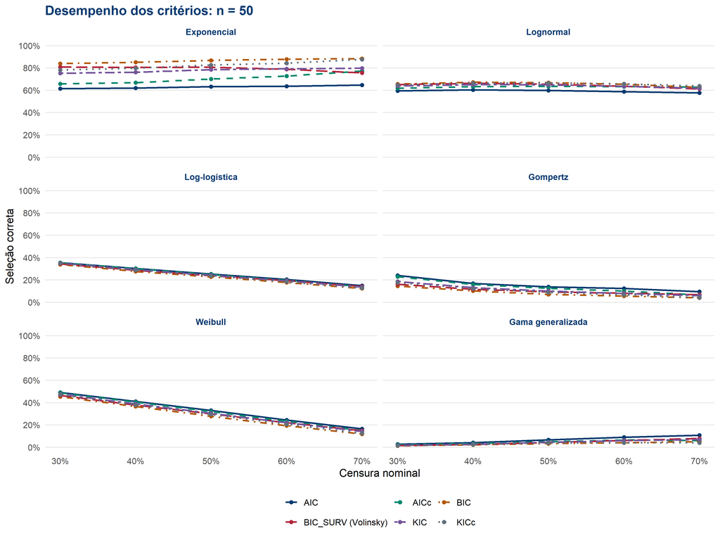

**Maior taxa observada em cada cenário.

| Distribuicao | Censura (%) | Maior acerto (%) | Critério(s) |
| --- | --- | --- | --- |
| Exponencial | 30 | 83,87 | BIC |
| Exponencial | 40 | 84,97 | BIC |
| Exponencial | 50 | 86,74 | BIC |
| Exponencial | 60 | 87,69 | BIC |
| Exponencial | 70 | 88,34 | BIC |
| Lognormal | 30 | 65,58 | BIC |
| Lognormal | 40 | 67,21 | BIC |
| Lognormal | 50 | 66,80 | BIC |
| Lognormal | 60 | 65,64 | KICc |
| Lognormal | 70 | 63,66 | KICc |
| Log-logística | 30 | 35,45 | AICc |
| Log-logística | 40 | 30,28 | AIC |
| Log-logística | 50 | 25,25 | AIC |
| Log-logística | 60 | 20,35 | AIC |
| Log-logística | 70 | 14,88 | AIC |
| Gompertz | 30 | 24,05 | AIC |
| Gompertz | 40 | 16,81 | AIC |
| Gompertz | 50 | 13,84 | AIC |
| Gompertz | 60 | 12,35 | AIC |
| Gompertz | 70 | 9,40 | AIC |
| Weibull | 30 | 49,12 | AIC |
| Weibull | 40 | 41,06 | AIC |
| Weibull | 50 | 33,01 | AIC |
| Weibull | 60 | 24,28 | AIC |
| Weibull | 70 | 16,55 | AIC |
| Gama generalizada | 30 | 2,65 | AIC |
| Gama generalizada | 40 | 4,03 | AIC |
| Gama generalizada | 50 | 6,61 | AIC |
| Gama generalizada | 60 | 8,99 | AIC |
| Gama generalizada | 70 | 10,79 | AIC |

## 3.2 n = 100

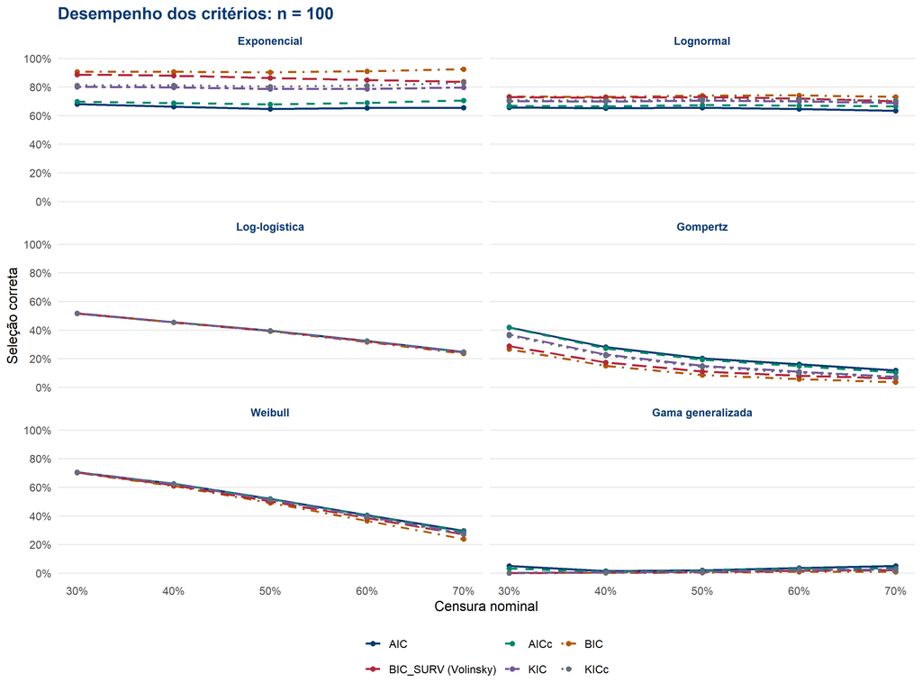

**Maior taxa observada em cada cenário.

| Distribuicao | Censura (%) | Maior acerto (%) | Critério(s) |
| --- | --- | --- | --- |
| Exponencial | 30 | 90,63 | BIC |
| Exponencial | 40 | 90,68 | BIC |
| Exponencial | 50 | 90,32 | BIC |
| Exponencial | 60 | 91,00 | BIC |
| Exponencial | 70 | 92,36 | BIC |
| Lognormal | 30 | 73,31 | BIC |
| Lognormal | 40 | 73,09 | BIC |
| Lognormal | 50 | 73,93 | BIC |
| Lognormal | 60 | 74,04 | BIC |
| Lognormal | 70 | 73,08 | BIC |
| Log-logística | 30 | 51,77 | KIC |
| Log-logística | 40 | 45,49 | AIC |
| Log-logística | 50 | 39,53 | AIC |
| Log-logística | 60 | 32,38 | AIC |
| Log-logística | 70 | 24,74 | AIC |
| Gompertz | 30 | 41,95 | AIC |
| Gompertz | 40 | 28,04 | AIC |
| Gompertz | 50 | 20,18 | AIC |
| Gompertz | 60 | 16,08 | AIC |
| Gompertz | 70 | 11,74 | AIC |
| Weibull | 30 | 70,64 | KIC |
| Weibull | 40 | 62,58 | AIC |
| Weibull | 50 | 51,90 | AIC |
| Weibull | 60 | 40,47 | AIC |
| Weibull | 70 | 29,56 | AIC |
| Gama generalizada | 30 | 5,09 | AIC |
| Gama generalizada | 40 | 1,38 | AIC |
| Gama generalizada | 50 | 1,91 | AIC |
| Gama generalizada | 60 | 3,63 | AIC |
| Gama generalizada | 70 | 4,97 | AIC |

## 3.3 n = 250

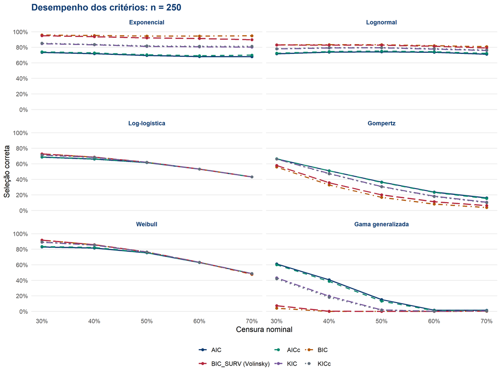

**Maior taxa observada em cada cenário.

| Distribuicao | Censura (%) | Maior acerto (%) | Critério(s) |
| --- | --- | --- | --- |
| Exponencial | 30 | 95,88 | BIC |
| Exponencial | 40 | 95,08 | BIC |
| Exponencial | 50 | 94,40 | BIC |
| Exponencial | 60 | 94,39 | BIC |
| Exponencial | 70 | 94,69 | BIC |
| Lognormal | 30 | 83,11 | BIC |
| Lognormal | 40 | 83,28 | BIC |
| Lognormal | 50 | 83,34 | BIC |
| Lognormal | 60 | 82,07 | BIC |
| Lognormal | 70 | 80,68 | BIC |
| Log-logística | 30 | 72,72 | BIC; BIC_SURV (Volinsky) |
| Log-logística | 40 | 68,53 | BIC; BIC_SURV (Volinsky) |
| Log-logística | 50 | 62,03 | BIC; BIC_SURV (Volinsky); KICc |
| Log-logística | 60 | 53,22 | BIC; BIC_SURV (Volinsky); KIC; KICc |
| Log-logística | 70 | 43,13 | AIC; AICc; BIC_SURV (Volinsky); KIC; KICc |
| Gompertz | 30 | 66,43 | AICc |
| Gompertz | 40 | 51,10 | AICc |
| Gompertz | 50 | 36,47 | AIC |
| Gompertz | 60 | 23,61 | AIC |
| Gompertz | 70 | 16,05 | AIC |
| Weibull | 30 | 91,72 | BIC |
| Weibull | 40 | 85,75 | BIC; BIC_SURV (Volinsky) |
| Weibull | 50 | 76,56 | BIC_SURV (Volinsky); KICc |
| Weibull | 60 | 63,28 | KIC |
| Weibull | 70 | 48,79 | KIC |
| Gama generalizada | 30 | 61,06 | AIC |
| Gama generalizada | 40 | 40,63 | AIC |
| Gama generalizada | 50 | 15,30 | AIC |
| Gama generalizada | 60 | 1,65 | AIC |
| Gama generalizada | 70 | 1,37 | AIC |

## 3.4 n = 500

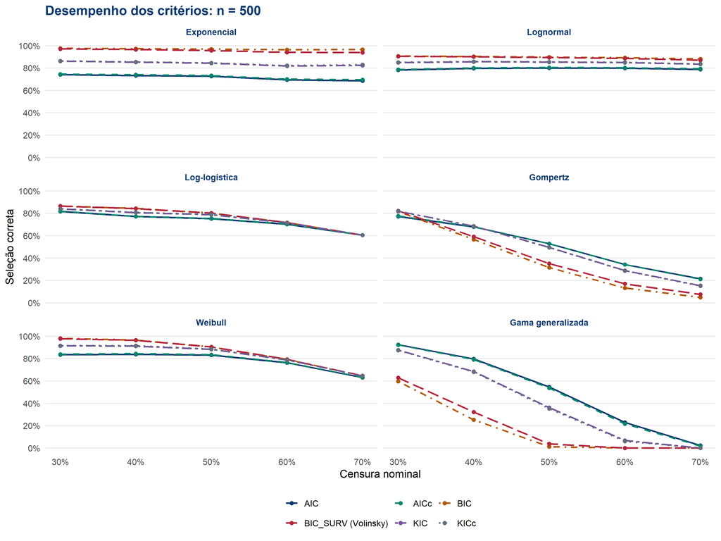

**Maior taxa observada em cada cenário.

| Distribuicao | Censura (%) | Maior acerto (%) | Critério(s) |
| --- | --- | --- | --- |
| Exponencial | 30 | 97,50 | BIC |
| Exponencial | 40 | 97,32 | BIC |
| Exponencial | 50 | 96,84 | BIC |
| Exponencial | 60 | 96,31 | BIC |
| Exponencial | 70 | 96,59 | BIC |
| Lognormal | 30 | 90,65 | BIC |
| Lognormal | 40 | 90,30 | BIC |
| Lognormal | 50 | 89,72 | BIC |
| Lognormal | 60 | 89,11 | BIC |
| Lognormal | 70 | 88,04 | BIC |
| Log-logística | 30 | 86,55 | BIC |
| Log-logística | 40 | 84,32 | BIC |
| Log-logística | 50 | 80,17 | BIC; BIC_SURV (Volinsky) |
| Log-logística | 60 | 71,56 | BIC; BIC_SURV (Volinsky) |
| Log-logística | 70 | 60,57 | BIC; BIC_SURV (Volinsky); KIC; KICc |
| Gompertz | 30 | 82,14 | BIC_SURV (Volinsky) |
| Gompertz | 40 | 68,56 | KIC |
| Gompertz | 50 | 52,86 | AIC |
| Gompertz | 60 | 34,19 | AIC |
| Gompertz | 70 | 21,54 | AIC |
| Weibull | 30 | 98,13 | BIC |
| Weibull | 40 | 96,52 | BIC |
| Weibull | 50 | 90,53 | BIC |
| Weibull | 60 | 79,37 | BIC |
| Weibull | 70 | 64,64 | BIC_SURV (Volinsky) |
| Gama generalizada | 30 | 92,43 | AIC |
| Gama generalizada | 40 | 79,63 | AIC |
| Gama generalizada | 50 | 54,65 | AIC |
| Gama generalizada | 60 | 22,96 | AIC |
| Gama generalizada | 70 | 2,38 | AIC |

# 4 Comparação entre tamanhos amostrais

## 4.1 Mesma censura, diferentes amostras

O gráfico seguinte fixa a censura em **30%**. Assim, as mudanças entre amostras podem ser observadas sem variar simultaneamente esse fator. O parâmetro `censura_comparacao` pode ser alterado no cabeçalho do arquivo.

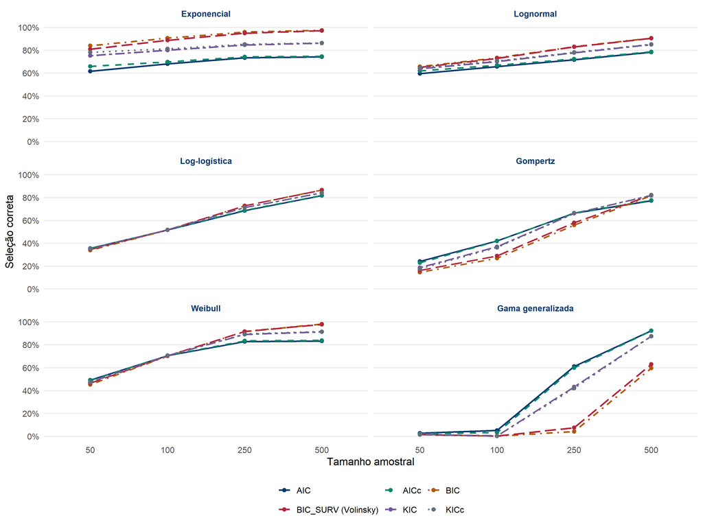

```r
d_comp <- filter(resultados, Censura == params$censura_comparacao)
if (nrow(d_comp)) {
  ggplot(d_comp, aes(factor(n, levels = tamanhos), Probabilidade,
                    colour = Criterio, linetype = Criterio, group = Criterio)) +
    geom_line(linewidth = 0.9) + geom_point(size = 1.9) +
    facet_wrap(~Distribuicao, ncol = 2, labeller = as_labeller(nomes_dist)) +
    scale_y_continuous(limits = c(0,100), breaks = seq(0,100,20), labels = function(x) paste0(x, "%")) +
    estilo_series() + tema + labs(x = "Tamanho amostral", y = "Seleção correta")
} else cat("O nível de censura selecionado não existe nos dados.")
```

## 4.2 Distribuição em foco

Aqui a distribuição geradora é **Gama generalizada**. Cada painel representa um critério, enquanto as linhas representam níveis de censura. Altere `distribuicao_foco` para um dos nomes originais dos arquivos, como `Weibull` ou `Gompertz`.

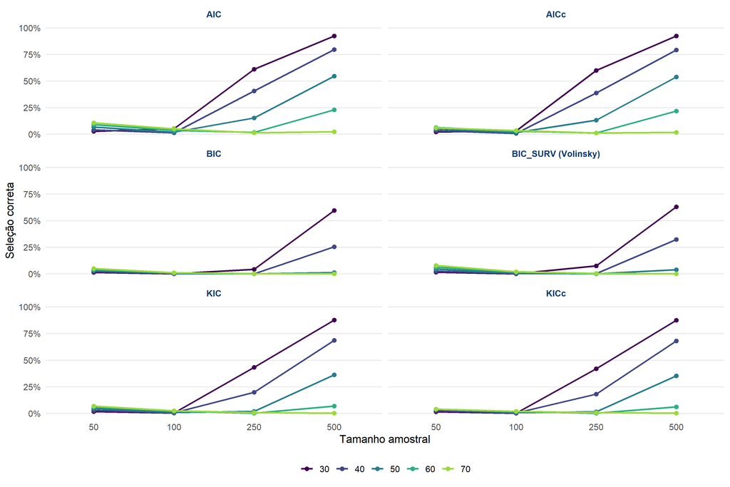

```r
d_foco <- filter(resultados, as.character(Distribuicao) == params$distribuicao_foco)
if (nrow(d_foco)) {
  ggplot(d_foco, aes(factor(n, levels = tamanhos), Probabilidade,
                    colour = factor(Censura), group = Censura)) +
    geom_line(linewidth = 0.9) + geom_point(size = 2) +
    facet_wrap(~Criterio, ncol = 2, labeller = as_labeller(nomes_crit)) +
    scale_colour_viridis_d(name = "Censura (%)", end = 0.85) +
    scale_y_continuous(limits = c(0,100), labels = function(x) paste0(x, "%")) +
    tema + labs(x = "Tamanho amostral", y = "Seleção correta")
} else cat("A distribuição selecionada não existe nos dados.")
```

# 5 Matrizes de seleção

As linhas indicam a **distribuição geradora** e as colunas, a **distribuição escolhida**. Os percentuais usam o total registrado de cada linha. A diagonal representa seleção correta. Fora dela, identificamos quais modelos receberam as seleções incorretas. Isso não mede, isoladamente, a qualidade preditiva dos modelos.

Este recorte usa **AIC** e **30% de censura**. Altere esses parâmetros para explorar outros recortes. Células omitidas em grupos presentes nos arquivos são completadas com frequência zero.

## 5.1 n = 50

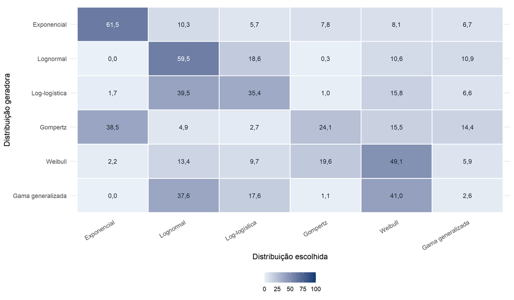

**Dez maiores percentuais fora da diagonal neste recorte:**

| Geradora | Escolhida | Frequencia | Percentual da linha (%) |
| --- | --- | --- | --- |
| Gama generalizada | Weibull | 4096 | 40,96 |
| Log-logística | Lognormal | 3945 | 39,45 |
| Gompertz | Exponencial | 3846 | 38,46 |
| Gama generalizada | Lognormal | 3761 | 37,61 |
| Weibull | Gompertz | 1960 | 19,60 |
| Lognormal | Log-logística | 1864 | 18,64 |
| Gama generalizada | Log-logística | 1764 | 17,64 |
| Log-logística | Weibull | 1576 | 15,76 |
| Gompertz | Weibull | 1551 | 15,51 |
| Gompertz | Gama generalizada | 1436 | 14,36 |

## 5.2 n = 100

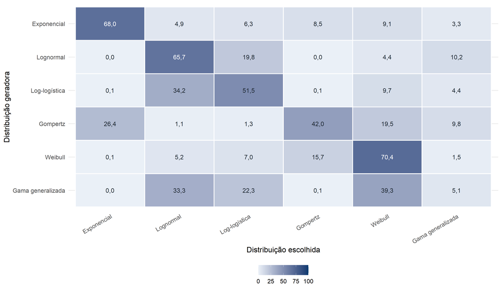

**Dez maiores percentuais fora da diagonal neste recorte:**

| Geradora | Escolhida | Frequencia | Percentual da linha (%) |
| --- | --- | --- | --- |
| Gama generalizada | Weibull | 3927 | 39,27 |
| Log-logística | Lognormal | 3424 | 34,24 |
| Gama generalizada | Lognormal | 3331 | 33,31 |
| Gompertz | Exponencial | 2641 | 26,41 |
| Gama generalizada | Log-logística | 2227 | 22,27 |
| Lognormal | Log-logística | 1983 | 19,83 |
| Gompertz | Weibull | 1951 | 19,51 |
| Weibull | Gompertz | 1571 | 15,71 |
| Lognormal | Gama generalizada | 1015 | 10,15 |
| Gompertz | Gama generalizada | 976 | 9,76 |

## 5.3 n = 250

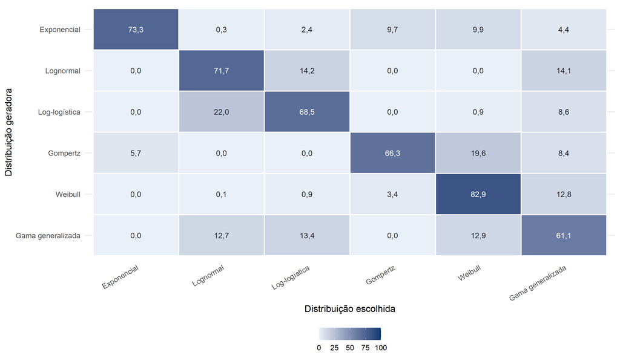

**Dez maiores percentuais fora da diagonal neste recorte:**

| Geradora | Escolhida | Frequencia | Percentual da linha (%) |
| --- | --- | --- | --- |
| Log-logística | Lognormal | 2200 | 22,00 |
| Gompertz | Weibull | 1962 | 19,62 |
| Lognormal | Log-logística | 1422 | 14,22 |
| Lognormal | Gama generalizada | 1407 | 14,07 |
| Gama generalizada | Log-logística | 1339 | 13,39 |
| Gama generalizada | Weibull | 1286 | 12,86 |
| Weibull | Gama generalizada | 1276 | 12,76 |
| Gama generalizada | Lognormal | 1269 | 12,69 |
| Exponencial | Weibull | 987 | 9,87 |
| Exponencial | Gompertz | 966 | 9,66 |

## 5.4 n = 500

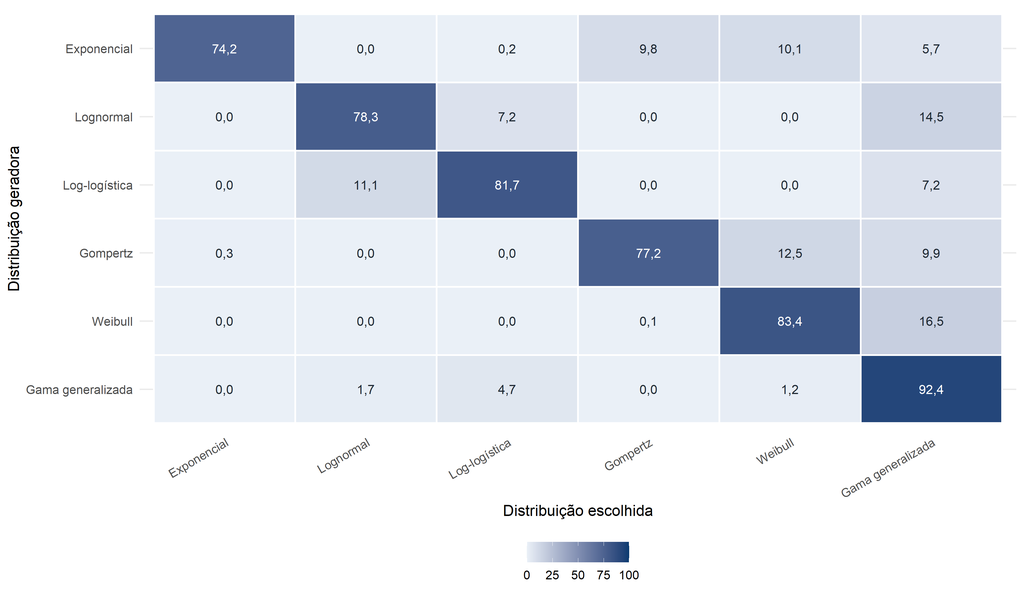

**Dez maiores percentuais fora da diagonal neste recorte:**

| Geradora | Escolhida | Frequencia | Percentual da linha (%) |
| --- | --- | --- | --- |
| Weibull | Gama generalizada | 1654 | 16,54 |
| Lognormal | Gama generalizada | 1450 | 14,50 |
| Gompertz | Weibull | 1251 | 12,51 |
| Log-logística | Lognormal | 1111 | 11,11 |
| Exponencial | Weibull | 1012 | 10,12 |
| Gompertz | Gama generalizada | 994 | 9,94 |
| Exponencial | Gompertz | 982 | 9,82 |
| Lognormal | Log-logística | 720 | 7,20 |
| Log-logística | Gama generalizada | 719 | 7,19 |
| Exponencial | Gama generalizada | 570 | 5,70 |

# 6 Precisão de Monte Carlo e conferência dos arquivos

O erro padrão de Monte Carlo da taxa de acerto é calculado por **100 × sqrt[p × (1 − p) / R]**, em pontos percentuais. Aqui, `p` é a taxa em proporção e `R` é o total de seleções registrado na matriz do cenário. Essa interpretação pressupõe repetições independentes.

| n | Taxas no resumo | Taxas com denominador | Maior EP de MC (p.p.) |
| --- | --- | --- | --- |
| 50 | 180 | 180 | 0.5 |
| 100 | 180 | 180 | 0.5 |
| 250 | 180 | 180 | 0.5 |
| 500 | 180 | 180 | 0.5 |

Foram conferidas **720 taxas** contra as diagonais das matrizes. A compilação é interrompida se houver duplicatas, percentuais inválidos ou discrepâncias superiores ao arredondamento de duas casas decimais.

Com 10.000 seleções independentes por cenário, o maior erro padrão possível é **0,50 ponto percentual**. O denominador observado não permite concluir se houve falhas anteriores de ajuste, exclusões ou novas tentativas. Essas informações precisam ser obtidas do código de simulação.

Os critérios podem avaliar as mesmas amostras simuladas. Por isso, o erro da **diferença entre critérios** depende de sua associação por repetição e não pode ser obtido apenas somando os erros individuais. Os arquivos agregados não permitem calcular essa associação. Os maiores percentuais são descritivos, sem testes de significância.

# 7 Síntese dos resultados fornecidos

- Na exponencial, com n = 500 e 30% de censura, o BIC apresenta **97,50%** de seleção correta.
- Na gama generalizada, nesse mesmo cenário, AIC e BIC apresentam **92,43%** e **59,56%**, respectivamente. A diferença observada é de **32,87 pontos percentuais**.
- Na gama generalizada, com n = 500 e 70% de censura, o acerto do AIC cai para **2,38%**. A vantagem relativa em alguns cenários não assegura alta taxa absoluta de acerto sob censura elevada.
- A interpretação deve considerar a distribuição geradora, a censura e o tamanho amostral. As conclusões se restringem às parametrizações simuladas. Não classificamos os modelos por número de parâmetros, pois essa informação não foi documentada nos arquivos recebidos.

# 8 Dados completos

## 8.1 Taxas de seleção correta

Use a busca e os filtros para localizar qualquer combinação. O erro padrão aparece em pontos percentuais; `R` é o total registrado na matriz.

| n | Distribuicao | Censura | Criterio | Acerto_percentual | R | EP_MC_pp |
| --- | --- | --- | --- | --- | --- | --- |
| 50 | Exponencial | 30 | AIC | 61.47 | 10000 | 0.4866661175795989 |
| 50 | Exponencial | 30 | AICc | 65.77 | 10000 | 0.4744794094584084 |
| 50 | Exponencial | 30 | BIC | 83.87 | 10000 | 0.3678074360314103 |
| 50 | Exponencial | 30 | BIC_SURV (Volinsky) | 80.76 | 10000 | 0.3941855400696479 |
| 50 | Exponencial | 30 | KIC | 75.26 | 10000 | 0.4315011471595412 |
| 50 | Exponencial | 30 | KICc | 78.14 | 10000 | 0.4132965521269201 |
| 50 | Exponencial | 40 | AIC | 62 | 10000 | 0.4853864439804639 |
| 50 | Exponencial | 40 | AICc | 66.82 | 10000 | 0.4708595969076132 |
| 50 | Exponencial | 40 | BIC | 84.97 | 10000 | 0.3573652333397864 |
| 50 | Exponencial | 40 | BIC_SURV (Volinsky) | 80.33 | 10000 | 0.3975035974679977 |

[output cut: 710 more lines]

## 8.2 Frequências das matrizes

Esta tabela preserva as células presentes nos arquivos originais. As células não registradas não aparecem aqui; nos gráficos de matrizes, elas são completadas como descrito acima.

| n | Censura | Criterio | Geradora | Escolhida | Frequencia | Percentual |
| --- | --- | --- | --- | --- | --- | --- |
| 50 | 30 | AIC | Lognormal | Exponencial | 1 | 0.01 |
| 50 | 30 | AIC | Lognormal | Gama generalizada | 1095 | 10.95 |
| 50 | 30 | AIC | Lognormal | Gompertz | 35 | 0.35 |
| 50 | 30 | AIC | Lognormal | Log-logística | 1864 | 18.64 |
| 50 | 30 | AIC | Lognormal | Lognormal | 5948 | 59.48 |
| 50 | 30 | AIC | Lognormal | Weibull | 1057 | 10.57 |
| 50 | 30 | BIC | Lognormal | Exponencial | 58 | 0.58 |
| 50 | 30 | BIC | Lognormal | Gama generalizada | 414 | 4.14 |
| 50 | 30 | BIC | Lognormal | Gompertz | 37 | 0.37 |
| 50 | 30 | BIC | Lognormal | Log-logística | 1892 | 18.92 |

[output cut: 3791 more lines]